# FAST Engine: knowledge base

NSF Regional Innovation Engines, Cohort 2. Technology profile v3.1. Draft, in progress

**NSF FAST Engine in Oregon**, led by Oregon State University. NSF award 2532464, start August 2026. Search window for papers and patents: from August 2021 (five years before the award) onward.

## At a glance

| Measure | Value |
| --- | --- |
| People named by NSF or the Engine’s site | 14 |
| of them active researchers (>= 5 works since window start) | 1 |
| Team members who are inventors (2021-2025 grants, in the region) | 2 |
| Partners (site list + team members’ organisations) | 105 |
| Knowledge-producer partners (universities, labs, institutes) | 6 |
| Partner papers in the Engine’s topics | 90 |
| of them with an in-region partner | 90 |
| Regional patents in the technology profile (2021-2025 grants) | 1108 |
| Location quotient of the technology profile (patents) | 5.65 |
| Share of regional technology patents owned by partners | 69.5% |

## Economic base

| NAICS | Industry | Employment in region | Establishments | Share of US employment | Employment LQ |
| --- | --- | --- | --- | --- | --- |
| 3344 | Semiconductor and other electronic components | 23,268 | 86 | 8.3% | 6.85 |
| 3345 | Navigational, measuring, electromedical and control instruments | 5,487 | 89 | 1.3% | 1.09 |
| 5415 | Computer systems design and related services | 11,651 | 1,425 | 0.6% | 0.47 |

Industries related to the Engine’s technology (chosen from the NSF abstract, see `data/manual/engine_naics.csv`). County Business Patterns 2023; LQ = the industry’s share of regional employment relative to its share of US employment (1 = US average). Region: whole state(s).

## Technology profile

Version 3.1, core. The NSF abstract names 2 technologies of this Engine (scientific and technical fragments extracted with a fixed prompt; the extraction was done by hand in a chat session, not reproducible). For each technology, all 4,516 OpenAlex topics and all CPC main groups are ranked by several independent signals; the core keeps up to 2 topics and 2 CPC main groups per technology. *Judge*: chosen by a rubric judge where no candidate was confirmed by two kinds of evidence (also by hand in a chat session). An empty cell: no suitable item among the candidates. See Methodology and the comparison of versions.

| # | Technology | OpenAlex topics | CPC main groups |
| --- | --- | --- | --- |
| 1 | semiconductors and advanced logic chips | T10363 Low-power high-performance VLSI design T10558 Advancements in Semiconductor Devices and Circuit Design | H10D89/00 Aspects of integrated devices not covered by groups H10D84/00 - H10D88/00 H10D84/00 Integrated devices formed in or on semiconductor substrates that comprise only semiconducting layers, e.g.… |
| 2 | AI-enabled Automatic Process Control | T10876 Fault Detection and Control Systems T14474 Industrial Technology and Control Systems | G05B15/00 Systems controlled by a computer (judge) Y10S706/00 Data processing: artificial intelligence (judge) |

## People

| Role | People |
| --- | --- |
| organizer | 12 |
| corporate_rd | 1 |
| researcher | 1 |

| Name | Role | On NSF award | Title | Organisation | Works since window (in Engine topics) | h-index | Patents 2021-25 (in Engine profile) | Site | OpenAlex |
| --- | --- | --- | --- | --- | --- | --- | --- | --- | --- |
| Pallavi Dhagat | researcher |  | FAST Co-Director of Research | Oregon State University | 21 (0) | 18 |  | [page](https://fast-engine.org/leadership/) | [profile](https://openalex.org/A5037916341) |
| Scott Mokler | corporate_rd |  | FAST Co-Director of Research | Intel, retired | 1 (0) | 4 | 3 (0) | [page](https://fast-engine.org/leadership/) | [profile](https://openalex.org/A5062941320) |
| Cara Turano | organizer |  | FAST Co-director of Translation, Entrepreneurship, and In… | Oregon Entrepreneur Network | - | - |  | [page](https://fast-engine.org/leadership/) |  |
| Christie Dudenhoefer | organizer |  | FAST Co-director of Partnership and Engagement | Oregon State University | - | - | 13 (0) | [page](https://fast-engine.org/leadership/) |  |
| Deb Mumm-Hill | organizer |  | FAST Co-Director of Workforce Development | STEM ED Consultant | - | - |  | [page](https://fast-engine.org/leadership/) |  |
| Julie Brandis | organizer |  | FAST Co-director of Partnership and Engagement | Oregon State University | - | - |  | [page](https://fast-engine.org/leadership/) |  |
| Kyle Ritchey-Noll | organizer |  | FAST Co-Director of Workforce Development | Oregon Business Council | - | - |  | [page](https://fast-engine.org/leadership/) |  |
| Larry Cheyne | organizer |  | FAST co-PI | Chemeketa College | - | - |  | [page](https://fast-engine.org/leadership/) |  |
| Rob Stone | organizer | PI | FAST Interim CEO | Oregon State University | - | - |  | [page](https://fast-engine.org/leadership/) |  |
| Shannon Carney | organizer | Co-PI | FAST co-PI | Business Oregon | - | - |  | [page](https://fast-engine.org/leadership/) |  |
| Shashi Jain | organizer |  | FAST Co-director of Translation, Entrepreneurship, and In… | Portland Seed Fund | - | - |  | [page](https://fast-engine.org/leadership/) |  |
| Skip Newberry | organizer | Co-PI | FAST Co-director of Translation, Entrepreneurship, and In… | Technology Association of Oregon | - | - |  | [page](https://fast-engine.org/leadership/) |  |
| Tim D Ray | organizer | Co-PI |  |  | - | - |  |  |  |
| Tina Guldberg | organizer | Co-PI | FAST Co-director of Partnership and Engagement | University of Oregon | - | - |  | [page](https://fast-engine.org/leadership/) |  |

Publication counts are shown only where the OpenAlex author matches both the name and the person’s current organisation. The OpenAlex link is given only for these reliable matches, and not for profiles flagged as possibly merging several namesakes. *Site* links to the page of the Engine’s website where the person is named. Click a number of works to see the list on the Publications page. *Patents*: US grants 2021-2025 with the person among the inventors (same last and first name, address in the Engine’s states); click the number for the list on the Patents page. In brackets: works in the Engine’s topics, patents with a CPC code in the Engine’s technology profile.

## Researchers at partner organisations

| # | Researcher | Partner | Works in the Engine’s topics | Citations | Years | Most cited of these works |
| --- | --- | --- | --- | --- | --- | --- |
| 1 | [Un-Ku Moon](https://openalex.org/A5005450048) | Oregon State University | 8 | 94 | 2022-2026 | [A 0.0375mm2 203.5µW 108.8dB DR DT Single-Loop DSM Audio A…](https://openalex.org/W4221105557) |
| 2 | [Matthew L. Johnston](https://openalex.org/A5008769831) | Oregon State University | 8 | 43 | 2021-2026 | [A Passive Wideband Noise-Canceling Mixer-First Architectu…](https://openalex.org/W4214863216) |
| 3 | [Arun S. Natarajan](https://openalex.org/A5091535060) | Oregon State University | 7 | 58 | 2022-2025 | [A Passive Wideband Noise-Canceling Mixer-First Architectu…](https://openalex.org/W4214863216) |
| 4 | [Gábor C. Temes](https://openalex.org/A5045933551) | Oregon State University | 7 | 24 | 2022-2025 | [A Second-Order Passive Noise-Shaping SAR ADC With 4× Pass…](https://openalex.org/W4312580016) |
| 5 | [John F. Wager](https://openalex.org/A5050764632) | Oregon State University | 6 | 25 | 2022-2026 | [Thin-film transistor accumulation-mode modeling](https://openalex.org/W4288061071) |
| 6 | [Cameron Souza](https://openalex.org/A5152017317) | Oregon State University | 6 | 0 | 2026 | [Forecast lead time is not a proper score for fault detect…](https://openalex.org/W7213504306) |
| 7 | [Hanyu Wang](https://openalex.org/A5100713367) | Oregon State University | 5 | 22 | 2022-2025 | [A Second-Order Passive Noise-Shaping SAR ADC With 4× Pass…](https://openalex.org/W4312580016) |
| 8 | [Xiaoyu Song](https://openalex.org/A5082437433) | Portland State University | 5 | 17 | 2022-2026 | [Constructing High Radix Quotient Digit Selection Tables f…](https://openalex.org/W4315473084) |
| 9 | [Tejasvi Anand](https://openalex.org/A5052751344) | Oregon State University | 5 | 13 | 2022-2026 | [A Single-Clock-Phase Sense Amplifier Architecture with 9x…](https://openalex.org/W4286571772) |
| 10 | [Manxin Li](https://openalex.org/A5076269615) | Oregon State University | 4 | 53 | 2023-2026 | [10.4 A Rail-to-Rail 12MS 91.3dB SNDR 94.1dB DR Two-Step S…](https://openalex.org/W4360606480) |
| 11 | [Ramin Javadi](https://openalex.org/A5099841558) | Oregon State University | 4 | 7 | 2024-2026 | [A 3.2pJ/b 0.068pJ/b/dB 25Gb/s NRZ Wireline Transceiver wi…](https://openalex.org/W4412965107) |
| 12 | [Christof Teuscher](https://openalex.org/A5037611164) | Portland State University | 4 | 3 | 2024-2026 | [General Principles for Implementing Branch Prediction in …](https://openalex.org/W4407364749) |
| 13 | [Byron Gregg](https://openalex.org/A5114900055) | Portland State University | 4 | 3 | 2024-2026 | [General Principles for Implementing Branch Prediction in …](https://openalex.org/W4407364749) |
| 14 | [Calvin Yoji Lee](https://openalex.org/A5017351381) | Oregon State University | 3 | 92 | 2022-2023 | [A 0.0375mm2 203.5µW 108.8dB DR DT Single-Loop DSM Audio A…](https://openalex.org/W4221105557) |
| 15 | [Hayden Bialek](https://openalex.org/A5006652711) | Oregon State University | 3 | 37 | 2022-2023 | [A Passive Wideband Noise-Canceling Mixer-First Architectu…](https://openalex.org/W4214863216) |

The grant names mostly managers; the technology is often developed at the partner universities and labs. These are the authors with the most works in the Engine’s OpenAlex topics written at a knowledge-producer partner in the Engine’s states, since the window start (at least 3 works; top 15). The list depends on the technology profile version. OpenAlex sometimes merges namesakes into one author: check the profile before relying on a name.

## Partners

| Organisation class | Partners |
| --- | --- |
| intermediary | 37 |
| company | 33 |
| government | 11 |
| community_college | 8 |
| investor | 8 |
| university | 5 |
| philanthropy | 2 |
| national_lab | 1 |

Partner list on the site: *Complete (100 partners + 14 core partner logos)*.

| Partner | Class | State | OpenAlex works since window (all topics) |
| --- | --- | --- | --- |
| Pacific Northwest National Laboratory | national_lab | Washington | 1362797 |
| Oregon State University | university | Oregon | 30915 |
| University of Oregon | university | Oregon | 14993 |
| Portland State University | university | Oregon | 11194 |
| Willamette University | university | Oregon | 710 |
| Oregon Institute of Technology | university | Oregon | 471 |

## Science base: partner papers in the Engine’s topics

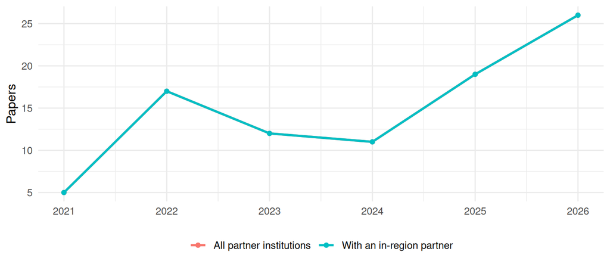

| Partner | Papers in topics |
| --- | --- |
| Oregon State University | 59 |
| Portland State University | 24 |
| Oregon Institute of Technology | 4 |
| University of Oregon | 3 |

## Technology base: patents

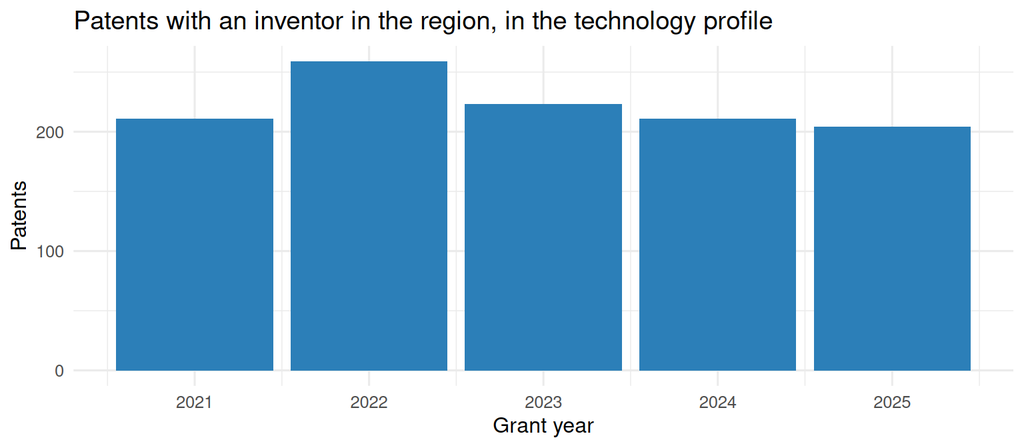

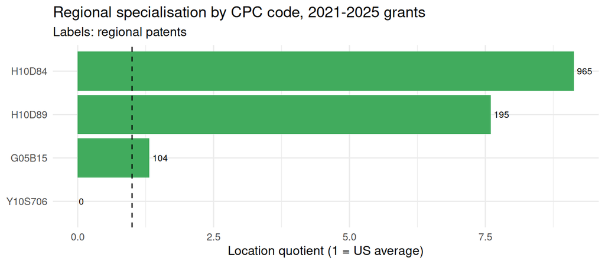

| Assignee | Regional patents in profile |
| --- | --- |
| Intel Corporation | 715 |
| Monolithic 3D Inc. | 136 |
| Kepler Computing Inc. | 43 |
| State Farm Mutual Automobile Insurance Company | 38 |
| NIKE, Inc. | 32 |
| Taiwan Semiconductor Manufacturing Company, Ltd. | 27 |
| SEMICONDUCTOR COMPONENTS INDUSTRIES, LLC | 11 |
| Taiwan Semiconductor Manufacturing Co., Ltd. | 7 |
| Tahoe Research, Ltd. | 6 |
| Applied Materials, Inc. | 5 |

Partner-owned patents invented in the region: 7408, of which 770 (10.4%) fall in the Engine’s technology profile.

## Competition

With 1108 patents in the technology profile (2021-2025 grants), the Engine’s region would rank **3** among US states; its specialisation (LQ) is 5.647.

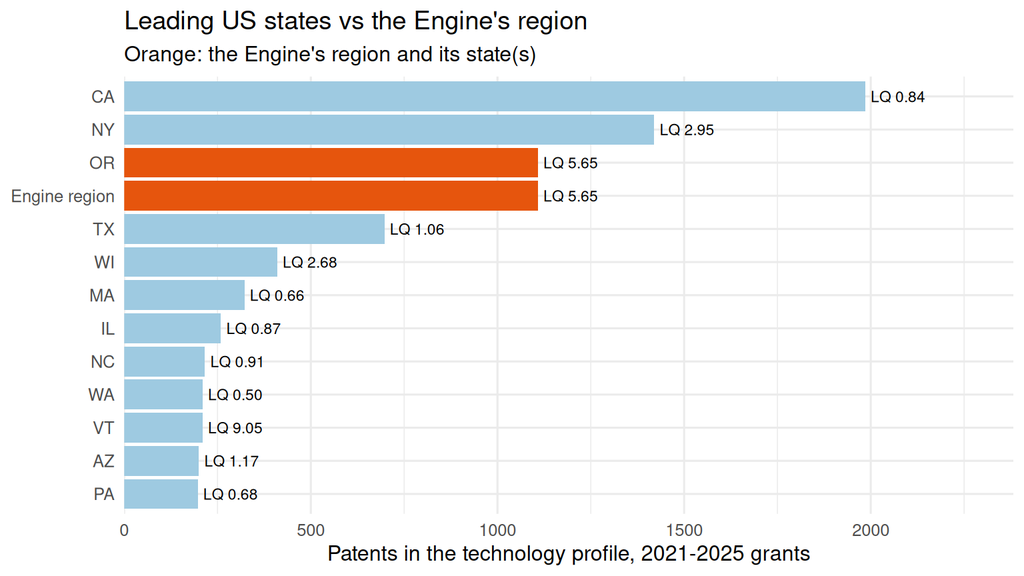

| Country | Share of US patents in profile | Share of world papers in topics |
| --- | --- | --- |
| US | 36.8% | 8.7% |
| TW | 32.5% | 2.0% |
| JP | 11.4% | 2.0% |
| KR | 8.1% | 4.2% |
| CN | 5.9% | 32.4% |
| DE | 2.3% | 3.2% |
| IN | 1.6% | 11.4% |
| FR | 1.4% | 2.4% |
| IL | 1.1% | NA |
| CA | 0.8% | 1.7% |

Patents: inventor countries on US grants in the profile (a patent counts for every country of its inventors). Papers: author countries of OpenAlex works in the Engine’s topics since the window start.

## Data and limitations

- People: PIs and Co-PIs from the NSF Award API; leadership listed on the Engine’s website. Roles come from titles and organisations, revised with OpenAlex evidence.
- Partners: as listed on the Engine’s website, plus organisations of team members. Some Engines publish partner logos without names.
- Region: the Engine’s counties where the list is known (NEO-SMART: 18 Northeast Ohio counties; STELLAR: 11 counties from the NSF abstract), otherwise its states (state-level proxy).
- Technology profile: v3.1 (switch versions in the header). Partner papers and regional patents depend on it: v1 uses mostly CPC subclasses, the v3.1 core uses CPC main groups, which are narrower, so it counts fewer patents and the LQ of a small region rests on few patents.
- Papers: OpenAlex; partner papers are restricted to the Engine’s OpenAlex topics.
- Patents: USPTO grants 2021-2025; inventor locations from PatentsView; pre-grant publications are not included.